# Spatial Data in R

Prof. Harbert

11 June, 2019

## Installing necessary packages

For the next few lessons you will need:

```r
install.packages('dismo')
install.packages('raster')
install.packages('spocc')
install.packages('ENMeval')
install.packages('mapr')
```

### Review data sources

We will be getting data for distribution modeling from:

- [WorldClim](https://www.worldclim.org)
- [GBIF](https://www.gbif.org)
- [iNaturalist](https://www.inaturalist.org)

# Geographic data: Continuous surfaces – > Raster data objects

Geographic data that are continuous across your study area can be represented as a gridded image-like data type known as a raster. These are basically really big 2 dimensional tables but with special attributes that help align the values in the matrix across the curved surface of Earth.

Our primary raster data will be climate. We will get that from the WorldClim project.

### Downloading climate data: WorldClim

We can download climate data for land masses except Antarctica using the ‘raster’ library and:

```r
library(raster)
clim = getData('worldclim', var='bio', res=5)

summary(clim)
```

```
##            bio1    bio2    bio3       bio4    bio5    bio6    bio7    bio8
## Min.       -263      34       9     119.00     -59    -540      60    -242
## 1st Qu.     -40      87      21    3931.75     192    -272     243      88
## Median       86     110      32    8098.00     271     -76     343     157
## 3rd Qu.     226     135      52   12543.25     332      87     456     243
## Max.        314     210      94   22679.00     488     255     724     373
## NA's    5476792 5476792 5476792 5476792.00 5476792 5476792 5476792 5476715
##            bio9   bio10      bio11   bio12   bio13   bio14   bio15   bio16
## Min.       -451     -95    -488.00       0       0       0       0       0
## 1st Qu.    -150     117    -203.25     259      45       3      34     116
## Median       37     196     -19.00     492      78      11      54     209
## 3rd Qu.     221     265     168.00     929     150      25      81     396
## Max.        360     378     286.00    8967    1654     590     229    3821
## NA's    5476637 5476792 5476792.00 5476559 5476559 5476559 5476559 5476559
##           bio17   bio18   bio19
## Min.          0       0       0
## 1st Qu.      13      84      24
## Median       39     173      57
## 3rd Qu.      89     273     126
## Max.       1887    2936    3151
## NA's    5476559 5476792 5476792
```

```r
summary(clim[[1]])
```

[output not shown]

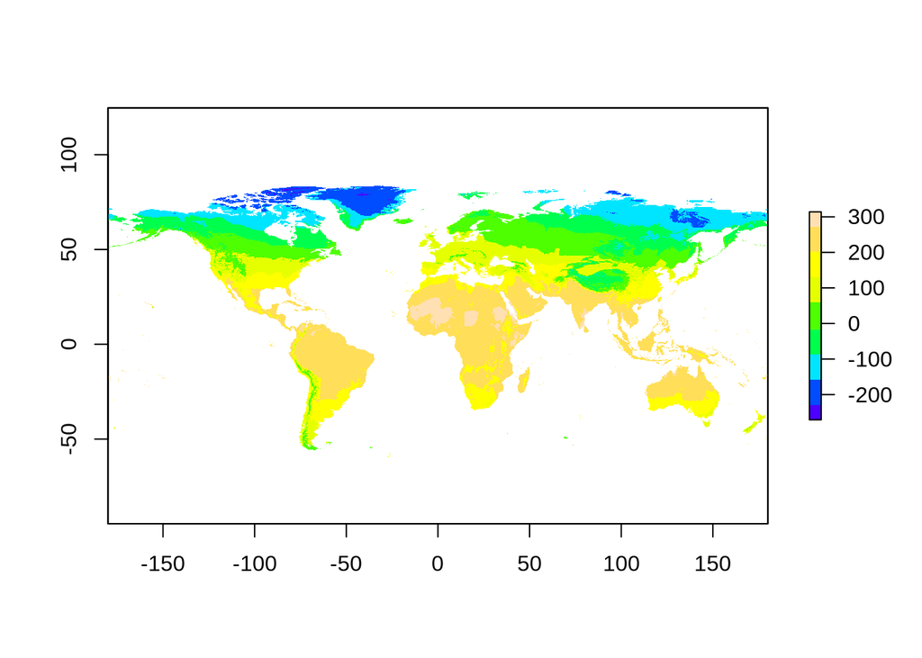

```r
plot(clim[[1]], col= topo.colors(9))
```

See [here](https://www.worldclim.org/bioclim) for Bioclim variable definitions.

We are looking at ‘bio1’ above which is the mean annual temperature value in Celsius degrees * 10.

### Raster operations: Crop

If we want to ‘zoom in’ on a region of interest we can crop the raster just like a picture file. However, we must use the coordinates of the raster. In this case that is latitude and longitude in decimal degrees.

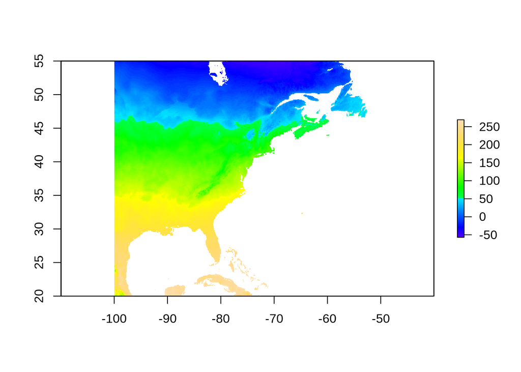

```r
#define an 'extent' object.
#eastern US
ext = extent(-100, -50, 20, 55)

#crop
c2 = crop(clim, ext)
plot(c2[[1]], col=topo.colors(99))
```

# Next time: Points data, mining GBIF/iNaturalist, and later ENMeval for distribution modeling.

[NEXT >>](https://rsh249.github.io/semester-biology/ENM/primary_biodiv.html)